# OncologyData-Pandas-Seaborn

## Part 1: Loading and Inspecting our data

. Before we begin inspecting our data we will need to load it by using pandas built in function *read_csv*. This will read our CSV file and load our data to a pandas *DataFrame* Object.

## Pandas

. Pandas is a flexible python library we will be using to create our DataFrame for data manipulation and analysis.

## Matplotlib/Pyplot

. Matplotlib is a plotting python 2D library. Pyplot is a command style function that makes Matplotlib work like MATLAB. Simplier version of Seaborn.

## Seaborn

. Seaborn is a python library used for visualization, a more enhanced version of Matplotlib

```python
#Import the proper libraries
import pandas as pd
import matplotlib.pyplot as plt
import seaborn as sns

#This line is used to make plots show inline
%matplotlib inline
```

```python
#To retrieve our data simply read it as a csv file and assign it to a respective variable
df = pd.read_csv("/Users/princeamankwah/Desktop/mock_treatment.csv")
```

## Health Care Data Analysis

. We will be exploring an oncology treatment data set which contains information about aritfical patients.

```python
#Lets take a look at the first 5 rows of our DataFrame
df.head()
```

|  | PatientID | TreatmentStart | Drug | Dosage |
| --- | --- | --- | --- | --- |
| 0 | PT1 | 1/14/16 | Cisplatin | 200 |
| 1 | PT20 | 1/2/16 | Cisplatin | 140 |
| 2 | PT2 | 1/10/16 | Cisplatin | 180 |
| 3 | PT3 | 1/24/16 | Cisplatin | 140 |
| 4 | PT4 | 2/14/16 | Cisplatin | 200 |

```python
#Lets obtain some descriptive statistics on our DataFrame
df.describe()
```

|  | Dosage |
| --- | --- |
| count | 24.000000 |
| mean | 264.583333 |
| std | 328.963843 |
| min | 140.000000 |
| 25% | 180.000000 |
| 50% | 195.000000 |
| 75% | 240.000000 |
| max | 1800.000000 |

###### Note: The first thing I noticed after observing basic statistics is the high number of max Dosage. Compared to the other values, max Dosage is significantly higher. This may indicate a typo.

```python
#Observe the data types of our columns
df.dtypes
```

```
PatientID         object
TreatmentStart    object
Drug              object
Dosage             int64
dtype: object
```

```python
#Observe the number of rows of our data set
len(df)
```

```
24
```

## Accessing columns in our dataframe

```python
df.columns
```

```
Index(['PatientID', 'TreatmentStart', 'Drug', 'Dosage'], dtype='object')
```

```python
#Obtain each row in our PatientID column in tabular form. Notice the two brackets which gives it a DataFrame format
df[['PatientID']].head()
```

|  | PatientID |
| --- | --- |
| 0 | PT1 |
| 1 | PT20 |
| 2 | PT2 |
| 3 | PT3 |
| 4 | PT4 |

```python
df[['TreatmentStart']].head()
```

|  | TreatmentStart |
| --- | --- |
| 0 | 1/14/16 |
| 1 | 1/2/16 |
| 2 | 1/10/16 |
| 3 | 1/24/16 |
| 4 | 2/14/16 |

```python
df[['Drug']].head()
```

|  | Drug |
| --- | --- |
| 0 | Cisplatin |
| 1 | Cisplatin |
| 2 | Cisplatin |
| 3 | Cisplatin |
| 4 | Cisplatin |

```python
df[['Dosage']].head()
```

|  | Dosage |
| --- | --- |
| 0 | 200 |
| 1 | 140 |
| 2 | 180 |
| 3 | 140 |
| 4 | 200 |

```python
#Obtain the unique values for pateintID in Series form.
df['PatientID'].unique()
```

```
array(['PT1', 'PT20', 'PT2', 'PT3', 'PT4', 'PT19', 'PT5', 'PT6', 'PT7',
       'PT8', 'PT9', 'PT10', 'PT11', 'PT16', 'PT12', 'PT13', 'PT14',
       'PT15', 'PT17', 'PT18'], dtype=object)
```

```python
#Obatin the unique drugs in our DataFrame in Series form
df['Drug'].unique()
```

```
array(['Cisplatin', 'Nivolumab'], dtype=object)
```

```python
#Obtain the first row in our DataFrame
df.iloc[[0]]
```

|  | PatientID | TreatmentStart | Drug | Dosage |
| --- | --- | --- | --- | --- |
| 0 | PT1 | 1/14/16 | Cisplatin | 200 |

```python
#Obtain 5 rows in our DataFrame excluding the first row
df.iloc[1:6]
```

|  | PatientID | TreatmentStart | Drug | Dosage |
| --- | --- | --- | --- | --- |
| 1 | PT20 | 1/2/16 | Cisplatin | 140 |
| 2 | PT2 | 1/10/16 | Cisplatin | 180 |
| 3 | PT3 | 1/24/16 | Cisplatin | 140 |
| 4 | PT4 | 2/14/16 | Cisplatin | 200 |
| 5 | PT19 | 2/10/16 | Cisplatin | 180 |

```python
#Obtain the row(s) where PatientID is PT19
df.loc[df['PatientID'] == 'PT19']
```

|  | PatientID | TreatmentStart | Drug | Dosage |
| --- | --- | --- | --- | --- |
| 5 | PT19 | 2/10/16 | Cisplatin | 180 |
| 22 | PT19 | 6/2/16 | Nivolumab | 240 |

```python
#Obtain the row(s) where PatientID is PT20 & the Drug is Cisplatin
df.loc[
    (df['PatientID'] == 'PT20') &
    (df['Drug'] == 'Cisplatin')]
```

|  | PatientID | TreatmentStart | Drug | Dosage |
| --- | --- | --- | --- | --- |
| 1 | PT20 | 1/2/16 | Cisplatin | 140 |

```python
#Obtain rows where Dosage is greater than 180
df.loc[df['Dosage'] > 180]
```

|  | PatientID | TreatmentStart | Drug | Dosage |
| --- | --- | --- | --- | --- |
| 0 | PT1 | 1/14/16 | Cisplatin | 200 |
| 4 | PT4 | 2/14/16 | Cisplatin | 200 |
| 6 | PT5 | 2/6/16 | Cisplatin | 190 |
| 8 | PT7 | 3/1/16 | Cisplatin | 210 |
| 10 | PT9 | 3/27/16 | Nivolumab | 240 |
| 11 | PT10 | 4/7/16 | Nivolumab | 240 |
| 13 | PT11 | 4/17/16 | Cisplatin | 190 |
| 15 | PT12 | 5/15/16 | Cisplatin | 1800 |
| 17 | PT14 | 5/3/16 | Nivolumab | 240 |
| 18 | PT15 | 5/7/16 | Nivolumab | 240 |
| 19 | PT1 | 6/17/16 | Nivolumab | 240 |
| 21 | PT18 | 6/3/16 | Nivolumab | 240 |
| 22 | PT19 | 6/2/16 | Nivolumab | 240 |
| 23 | PT20 | 6/2/16 | Nivolumab | 240 |

# Part 2: Data Cleaning

## Lets clean up our Dosage Column by updating a row

```python
#As you can see we have a typo in our Dosage column. We have a max value of 1800 which is way above our normal value
#Lets update our row with 1800 to a value of 180
df['Dosage'].iloc[15] = 180
```

```python
#Observe our new table with updated Dosage column
df
```

|  | PatientID | TreatmentStart | Drug | Dosage |
| --- | --- | --- | --- | --- |
| 0 | PT1 | 1/14/16 | Cisplatin | 200 |
| 1 | PT20 | 1/2/16 | Cisplatin | 140 |
| 2 | PT2 | 1/10/16 | Cisplatin | 180 |
| 3 | PT3 | 1/24/16 | Cisplatin | 140 |
| 4 | PT4 | 2/14/16 | Cisplatin | 200 |
| 5 | PT19 | 2/10/16 | Cisplatin | 180 |
| 6 | PT5 | 2/6/16 | Cisplatin | 190 |
| 7 | PT6 | 3/1/16 | Cisplatin | 180 |
| 8 | PT7 | 3/1/16 | Cisplatin | 210 |
| 9 | PT8 | 3/19/16 | Cisplatin | 180 |
| 10 | PT9 | 3/27/16 | Nivolumab | 240 |
| 11 | PT10 | 4/7/16 | Nivolumab | 240 |
| 12 | PT10 | 4/7/16 | Cisplatin | 140 |
| 13 | PT11 | 4/17/16 | Cisplatin | 190 |
| 14 | PT16 | 4/9/16 | Cisplatin | 160 |
| 15 | PT12 | 5/15/16 | Cisplatin | 180 |
| 16 | PT13 | 5/21/16 | Cisplatin | 180 |
| 17 | PT14 | 5/3/16 | Nivolumab | 240 |
| 18 | PT15 | 5/7/16 | Nivolumab | 240 |
| 19 | PT1 | 6/17/16 | Nivolumab | 240 |
| 20 | PT17 | 6/17/16 | Cisplatin | 160 |
| 21 | PT18 | 6/3/16 | Nivolumab | 240 |
| 22 | PT19 | 6/2/16 | Nivolumab | 240 |
| 23 | PT20 | 6/2/16 | Nivolumab | 240 |

```python
#Sort DataFrame by Date column
df.sort_values('TreatmentStart').head()
```

|  | PatientID | TreatmentStart | Drug | Dosage |
| --- | --- | --- | --- | --- |
| 2 | PT2 | 1/10/16 | Cisplatin | 180 |
| 0 | PT1 | 1/14/16 | Cisplatin | 200 |
| 1 | PT20 | 1/2/16 | Cisplatin | 140 |
| 3 | PT3 | 1/24/16 | Cisplatin | 140 |
| 5 | PT19 | 2/10/16 | Cisplatin | 180 |

###### Note: Notice how the date column is not properly sorted

. Lets clean up our TreatmentStart column

```python
#We first have to convert the TreatmentStart column to a datetime object then assign it to our Date column
df['TreatmentStart'] = pd.to_datetime(df['TreatmentStart'])
```

```python
#Observe our new Date column
df.head()
```

|  | PatientID | TreatmentStart | Drug | Dosage |
| --- | --- | --- | --- | --- |
| 0 | PT1 | 2016-01-14 | Cisplatin | 200 |
| 1 | PT20 | 2016-01-02 | Cisplatin | 140 |
| 2 | PT2 | 2016-01-10 | Cisplatin | 180 |
| 3 | PT3 | 2016-01-24 | Cisplatin | 140 |
| 4 | PT4 | 2016-02-14 | Cisplatin | 200 |

```python
#Sort our DataFrame in ascending order by our TreatmentStart column
df.sort_values(['TreatmentStart'], inplace=True)
```

```python
df.head()
```

|  | PatientID | TreatmentStart | Drug | Dosage |
| --- | --- | --- | --- | --- |
| 1 | PT20 | 2016-01-02 | Cisplatin | 140 |
| 2 | PT2 | 2016-01-10 | Cisplatin | 180 |
| 0 | PT1 | 2016-01-14 | Cisplatin | 200 |
| 3 | PT3 | 2016-01-24 | Cisplatin | 140 |
| 6 | PT5 | 2016-02-06 | Cisplatin | 190 |

```python
#Sort multiple columns. First sort the Patient column in ascending order then the TreatmentStart in descending order
df.sort_values(['PatientID', 'TreatmentStart'], ascending = [True, False]).head()
```

|  | PatientID | TreatmentStart | Drug | Dosage |
| --- | --- | --- | --- | --- |
| 19 | PT1 | 2016-06-17 | Nivolumab | 240 |
| 0 | PT1 | 2016-01-14 | Cisplatin | 200 |
| 12 | PT10 | 2016-04-07 | Cisplatin | 140 |
| 11 | PT10 | 2016-04-07 | Nivolumab | 240 |
| 13 | PT11 | 2016-04-17 | Cisplatin | 190 |

```python
#Sort the DataFrame by Dosage in descending order
df.sort_values('Dosage', ascending = False)
```

|  | PatientID | TreatmentStart | Drug | Dosage |
| --- | --- | --- | --- | --- |
| 11 | PT10 | 2016-04-07 | Nivolumab | 240 |
| 19 | PT1 | 2016-06-17 | Nivolumab | 240 |
| 18 | PT15 | 2016-05-07 | Nivolumab | 240 |
| 22 | PT19 | 2016-06-02 | Nivolumab | 240 |
| 10 | PT9 | 2016-03-27 | Nivolumab | 240 |
| 21 | PT18 | 2016-06-03 | Nivolumab | 240 |
| 17 | PT14 | 2016-05-03 | Nivolumab | 240 |
| 23 | PT20 | 2016-06-02 | Nivolumab | 240 |
| 8 | PT7 | 2016-03-01 | Cisplatin | 210 |
| 0 | PT1 | 2016-01-14 | Cisplatin | 200 |
| 4 | PT4 | 2016-02-14 | Cisplatin | 200 |
| 13 | PT11 | 2016-04-17 | Cisplatin | 190 |
| 6 | PT5 | 2016-02-06 | Cisplatin | 190 |
| 15 | PT12 | 2016-05-15 | Cisplatin | 180 |
| 9 | PT8 | 2016-03-19 | Cisplatin | 180 |
| 2 | PT2 | 2016-01-10 | Cisplatin | 180 |
| 7 | PT6 | 2016-03-01 | Cisplatin | 180 |
| 5 | PT19 | 2016-02-10 | Cisplatin | 180 |
| 16 | PT13 | 2016-05-21 | Cisplatin | 180 |
| 20 | PT17 | 2016-06-17 | Cisplatin | 160 |
| 14 | PT16 | 2016-04-09 | Cisplatin | 160 |
| 12 | PT10 | 2016-04-07 | Cisplatin | 140 |
| 3 | PT3 | 2016-01-24 | Cisplatin | 140 |
| 1 | PT20 | 2016-01-02 | Cisplatin | 140 |

## Data Analysis

```python
#Observe the number of patients
len(df['PatientID'])
```

```
24
```

```python
#Observe the number of unique patients
len(df['PatientID'].unique())
```

```
20
```

###### Note: As you can see there are 20 unique patients and the length of patients is 24, which means there are 4 Patients on two different medications

## Patients treated at practice

#### How many Patients does the practice treat?

```python
print("The practice treats:", len(df['PatientID'].unique()), 'patients')
```

```
The practice treats: 20 patients
```

## Drug usage at practice

#### What drugs are used at practice?

```python
#Implement the groupby() function to group the drugs in a DataFrame
df.groupby('Drug').count()
```

| Drug | PatientID | TreatmentStart | Dosage |
| --- | --- | --- | --- |
| Cisplatin | 16 | 16 | 16 |
| Nivolumab | 8 | 8 | 8 |

```python
#Format the above code correctly for better reading by using reset_index() function
df.groupby('Drug').count()[['PatientID', 'TreatmentStart', 'Dosage']].reset_index()
```

|  | Drug | PatientID | TreatmentStart | Dosage |
| --- | --- | --- | --- | --- |
| 0 | Cisplatin | 16 | 16 | 16 |
| 1 | Nivolumab | 8 | 8 | 8 |

```python
#Our DataFrame is still in the format we want. The above code did not permanently modify our DataFrame.
#To permanently modify our DataFrame we could've used inplace=True
df.head()
```

|  | PatientID | TreatmentStart | Drug | Dosage |
| --- | --- | --- | --- | --- |
| 1 | PT20 | 2016-01-02 | Cisplatin | 140 |
| 2 | PT2 | 2016-01-10 | Cisplatin | 180 |
| 0 | PT1 | 2016-01-14 | Cisplatin | 200 |
| 3 | PT3 | 2016-01-24 | Cisplatin | 140 |
| 6 | PT5 | 2016-02-06 | Cisplatin | 190 |

## Lets plot some information

### We will be comparing our Drug & PatientID Columns

#### Before plotting the comparison between Drug & PatientID, lets rename our PatientID column to PatientCount

```python
df.rename(columns={'PatientID' : 'PatientCount'}, inplace=True)
```

```python
df.head()
```

|  | PatientCount | TreatmentStart | Drug | Dosage |
| --- | --- | --- | --- | --- |
| 1 | PT20 | 2016-01-02 | Cisplatin | 140 |
| 2 | PT2 | 2016-01-10 | Cisplatin | 180 |
| 0 | PT1 | 2016-01-14 | Cisplatin | 200 |
| 3 | PT3 | 2016-01-24 | Cisplatin | 140 |
| 6 | PT5 | 2016-02-06 | Cisplatin | 190 |

#### Before plotting the comparison between Drug & Patient Count we have to assign that DataFrame to a variable for flexibility.

```python
counts = df.groupby('Drug').count()[['PatientCount']].reset_index()
```

```python
counts
```

|  | Drug | PatientCount |
| --- | --- | --- |
| 0 | Cisplatin | 16 |
| 1 | Nivolumab | 8 |

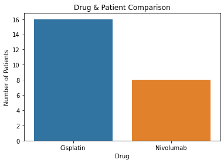

```python
#Lets begin by using a simple barchart to compare our 2 columns
fig = sns.barplot(data = counts, x = 'Drug', y = 'PatientCount')
plt.title('Drug & Patient Comparison')
plt.xlabel('Drug')
plt.ylabel('Number of Patients')
plt.show(fig)
```

#### Note: As shown above twice as many patients are taking Cisplatin compared to Nivolumab

### Changes to treatment overtime

#### Our current Dataset shows treatment by start date. But we would like to compare the changes in treatments by the month to see how many patients start a given drug overtime

```python
#Begin by creating a new column based only on TreatmentStart month
df['TreatmentStartMonth'] = df['TreatmentStart'].astype('datetime64[M]')
```

### Do we see any changes, patterns in treatment overtime?

```python
#Observe our new column
df.head()
```

|  | PatientCount | TreatmentStart | Drug | Dosage | TreatmentStartMonth |
| --- | --- | --- | --- | --- | --- |
| 1 | PT20 | 2016-01-02 | Cisplatin | 140 | 2016-01-01 |
| 2 | PT2 | 2016-01-10 | Cisplatin | 180 | 2016-01-01 |
| 0 | PT1 | 2016-01-14 | Cisplatin | 200 | 2016-01-01 |
| 3 | PT3 | 2016-01-24 | Cisplatin | 140 | 2016-01-01 |
| 6 | PT5 | 2016-02-06 | Cisplatin | 190 | 2016-02-01 |

```python
#Now implement the groupby() function to compare TreatmentStartMonth, Drug, only counting Patients
drug_by_month = df.groupby(['TreatmentStartMonth', 'Drug']).count()[['PatientCount']].reset_index()
```

```python
#Shown below is the the drug count started based on the month
drug_by_month
```

|  | TreatmentStartMonth | Drug | PatientCount |
| --- | --- | --- | --- |
| 0 | 2016-01-01 | Cisplatin | 4 |
| 1 | 2016-02-01 | Cisplatin | 3 |
| 2 | 2016-03-01 | Cisplatin | 3 |
| 3 | 2016-03-01 | Nivolumab | 1 |
| 4 | 2016-04-01 | Cisplatin | 3 |
| 5 | 2016-04-01 | Nivolumab | 1 |
| 6 | 2016-05-01 | Cisplatin | 2 |
| 7 | 2016-05-01 | Nivolumab | 2 |
| 8 | 2016-06-01 | Cisplatin | 1 |
| 9 | 2016-06-01 | Nivolumab | 4 |

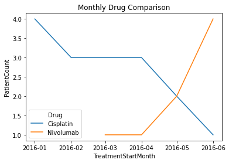

```python
#Now lets make use of Seaborn once again to visualize how many patients started each drug by month
#The hue keyword is used to distinguish two different categorical variables
fig = sns.lineplot(data = drug_by_month, x = 'TreatmentStartMonth', y = 'PatientCount', hue = 'Drug')
plt.title('Monthly Drug Comparison')
plt.show(fig)
```

### What is the average dosage of each drug?

```python
#Observe some descriptive statistics based on the Drug Column
df.groupby(['Drug']).describe().reset_index()
```

|  | Drug | Dosage count | Dosage mean | Dosage std | Dosage min | Dosage 25% | Dosage 50% | Dosage 75% | Dosage max |
| --- | --- | --- | --- | --- | --- | --- | --- | --- | --- |
| 0 | Cisplatin | 16.0 | 175.625 | 21.899391 | 140.0 | 160.0 | 180.0 | 190.0 | 210.0 |
| 1 | Nivolumab | 8.0 | 240.000 | 0.000000 | 240.0 | 240.0 | 240.0 | 240.0 | 240.0 |

#### Note: As shown above each value in row 1 besides count/standard deviation is 240 which means each patient who was under Nivolumab received a total dosage of 240.

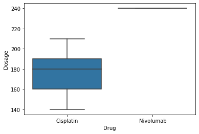

```python
#Below we're able to visually compare the average Dosage of each drug
fig = sns.boxplot(data = df, x = 'Drug', y = "Dosage", showfliers=False)
plt.show(fig)
```

## Summary

. In this analysis I was able to cover basic pandas concepts. Overall I was able to explore our data set with the help of pandas and seaborn library. Some data cleaning was also done to further analyze our data.

```python
df
```

|  | PatientCount | TreatmentStart | Drug | Dosage | TreatmentStartMonth |
| --- | --- | --- | --- | --- | --- |
| 1 | PT20 | 2016-01-02 | Cisplatin | 140 | 2016-01-01 |
| 2 | PT2 | 2016-01-10 | Cisplatin | 180 | 2016-01-01 |
| 0 | PT1 | 2016-01-14 | Cisplatin | 200 | 2016-01-01 |
| 3 | PT3 | 2016-01-24 | Cisplatin | 140 | 2016-01-01 |
| 6 | PT5 | 2016-02-06 | Cisplatin | 190 | 2016-02-01 |
| 5 | PT19 | 2016-02-10 | Cisplatin | 180 | 2016-02-01 |
| 4 | PT4 | 2016-02-14 | Cisplatin | 200 | 2016-02-01 |
| 7 | PT6 | 2016-03-01 | Cisplatin | 180 | 2016-03-01 |
| 8 | PT7 | 2016-03-01 | Cisplatin | 210 | 2016-03-01 |
| 9 | PT8 | 2016-03-19 | Cisplatin | 180 | 2016-03-01 |
| 10 | PT9 | 2016-03-27 | Nivolumab | 240 | 2016-03-01 |
| 12 | PT10 | 2016-04-07 | Cisplatin | 140 | 2016-04-01 |
| 11 | PT10 | 2016-04-07 | Nivolumab | 240 | 2016-04-01 |
| 14 | PT16 | 2016-04-09 | Cisplatin | 160 | 2016-04-01 |
| 13 | PT11 | 2016-04-17 | Cisplatin | 190 | 2016-04-01 |
| 17 | PT14 | 2016-05-03 | Nivolumab | 240 | 2016-05-01 |
| 18 | PT15 | 2016-05-07 | Nivolumab | 240 | 2016-05-01 |
| 15 | PT12 | 2016-05-15 | Cisplatin | 180 | 2016-05-01 |
| 16 | PT13 | 2016-05-21 | Cisplatin | 180 | 2016-05-01 |
| 22 | PT19 | 2016-06-02 | Nivolumab | 240 | 2016-06-01 |
| 23 | PT20 | 2016-06-02 | Nivolumab | 240 | 2016-06-01 |
| 21 | PT18 | 2016-06-03 | Nivolumab | 240 | 2016-06-01 |
| 19 | PT1 | 2016-06-17 | Nivolumab | 240 | 2016-06-01 |
| 20 | PT17 | 2016-06-17 | Cisplatin | 160 | 2016-06-01 |